# Missing value imputation using KNN

Harsha Achyuthuni

07/07/2019

## Problem

Real world data is not always clean. Its often messy and contains unexpected/missing values. In this post I will use a non-parametric algorithm called k-nearest-neighbors (KNN) to replace missing values.

### Data

The data is technical spec of cars. I have taken this data set from [UCI Machine learning repository](https://archive.ics.uci.edu/ml/datasets/auto+mpg) which in turn took it form StatLib library which is maintained at Carnegie Mellon University. The data set was used in the 1983 American Statistical Association Exposition.

Sample Data

| mpg | cylinders | displacement | horsepower | weight | acceleration | year | origin | name |
| --- | --- | --- | --- | --- | --- | --- | --- | --- |
| 20.0 | 6 | 156 | 122 | 2807 | 13.5 | 73 | 3 | toyota mark ii |
| 37.7 | 4 | 89 | 62 | 2050 | 17.3 | 81 | 3 | toyota tercel |
| 15.5 | 8 | 304 | 120 | 3962 | 13.9 | 76 | 1 | amc matador |
| 23.0 | 4 | 120 | 97 | 2506 | 14.5 | 72 | 3 | toyouta corona mark ii (sw) |
| 30.7 | 6 | 145 | 76 | 3160 | 19.6 | 81 | 2 | volvo diesel |

The data set contains the following columns:  
1. mpg: continuous (miles per gallon)  
2. cylinders: multi-valued discrete 3. displacement: continuous (cu. inches)  
4. horsepower: continuous  
5. weight: continuous(lbs.)  
6. acceleration: continuous (sec.)  
7. model year: multi-valued discrete (modulo 100)  
8. origin: multi-valued discrete (1. American, 2. European, 3. Japanese)  
9. car name: string (unique for each instance)

Now I want to find if this data set contains any abnormal values.

```r
summary(cars_info)
```

```
##       mpg          cylinders      displacement     horsepower        weight
##  Min.   : 9.00   Min.   :3.000   Min.   : 68.0   Min.   : 46.0   Min.   :1613
##  1st Qu.:17.50   1st Qu.:4.000   1st Qu.:104.0   1st Qu.: 75.0   1st Qu.:2223
##  Median :23.00   Median :4.000   Median :146.0   Median : 93.5   Median :2800
##  Mean   :23.52   Mean   :5.458   Mean   :193.5   Mean   :104.5   Mean   :2970
##  3rd Qu.:29.00   3rd Qu.:8.000   3rd Qu.:262.0   3rd Qu.:126.0   3rd Qu.:3609
##  Max.   :46.60   Max.   :8.000   Max.   :455.0   Max.   :230.0   Max.   :5140
##                                                  NA's   :5
##   acceleration        year       origin      name
##  Min.   : 8.00   Min.   :70.00   1:248   Length:397
##  1st Qu.:13.80   1st Qu.:73.00   2: 70   Class :character
##  Median :15.50   Median :76.00   3: 79   Mode  :character
##  Mean   :15.56   Mean   :75.99
##  3rd Qu.:17.10   3rd Qu.:79.00
##  Max.   :24.80   Max.   :82.00
##
```

I find that horsepower contains 5 NA values. I can ignore the data points with horsepower NA, or I could impute the NA values using KNN or other methods. Before imputing, I want to make a strong case that my imputation would be right.

Cars with missing horsepower

| mpg | cylinders | displacement | weight | acceleration | year | origin | name |
| --- | --- | --- | --- | --- | --- | --- | --- |
| 25.0 | 4 | 98 | 2046 | 19.0 | 71 | 1 | ford pinto |
| 21.0 | 6 | 200 | 2875 | 17.0 | 74 | 1 | ford maverick |
| 40.9 | 4 | 85 | 1835 | 17.3 | 80 | 2 | renault lecar deluxe |
| 23.6 | 4 | 140 | 2905 | 14.3 | 80 | 1 | ford mustang cobra |
| 34.5 | 4 | 100 | 2320 | 15.8 | 81 | 2 | renault 18i |

The assumption behind using KNN for missing values is that a point value can be approximated by the values of the points that are closest to it, based on other variables.  
Let me take three variables from the above data set, mpg, acceleration and horsepower. Intuitively, these variables seem to be related.

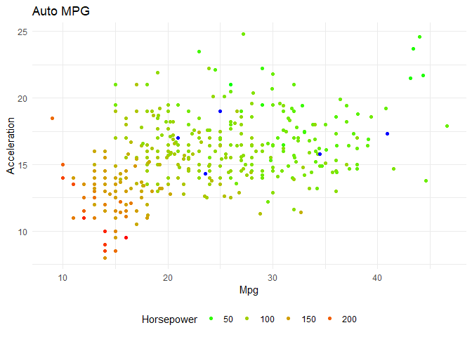

```r
ggplot(cars_info, aes(x = mpg, y = acceleration, color = horsepower)) +
  geom_point(show.legend = TRUE) +
  labs(x = 'Mpg', y='Acceleration',  title = "Auto MPG",
       color = 'Horsepower') +
  scale_color_gradient(low = "green", high = "red",
                       na.value = "blue", guide = "legend") +
  theme_minimal()+theme(legend.position="bottom")
```

```r
library(caret)
preProcValues <- preProcess(cars_info %>%
                          dplyr::select(mpg, cylinders, displacement, weight, acceleration, origin, horsepower),
                            method = c("knnImpute"),
                            k = 20,
                            knnSummary = mean)
impute_cars_info <- predict(preProcValues, cars_info,na.action = na.pass)
```

The *impute_cars_info* data set will be normalized. To de-normalize and get the original data back:

```r
procNames <- data.frame(col = names(preProcValues$mean), mean = preProcValues$mean, sd = preProcValues$std)
for(i in procNames$col){
 impute_cars_info[i] <- impute_cars_info[i]*preProcValues$std[i]+preProcValues$mean[i]
}
```

The imputed horsepower for the missing data points is:

Imputed data set

| name | year | origin | mpg | cylinders | displacement | weight | acceleration | horsepower |
| --- | --- | --- | --- | --- | --- | --- | --- | --- |
| ford maverick | 74 | 1 | 21.0 | 6 | 200 | 2875 | 17.0 | 93.60 |
| ford mustang cobra | 80 | 1 | 23.6 | 4 | 140 | 2905 | 14.3 | 94.95 |
| ford pinto | 71 | 1 | 25.0 | 4 | 98 | 2046 | 19.0 | 72.45 |
| renault 18i | 81 | 2 | 34.5 | 4 | 100 | 2320 | 15.8 | 73.75 |
| renault lecar deluxe | 80 | 2 | 40.9 | 4 | 85 | 1835 | 17.3 | 65.10 |

The actual hp for the cars are as follows:

Comparison

| name | year | horsepower | actual_hp | difference |
| --- | --- | --- | --- | --- |
| ford maverick | 74 | 93.60 | 84 | 9.60 |
| ford mustang cobra | 80 | 94.95 | 118 | 23.05 |
| ford pinto | 71 | 72.45 | 100 | 27.55 |
| renault 18i | 81 | 73.75 | 81 | 7.25 |
| renault lecar deluxe | 80 | 65.10 | 51 | 14.10 |